# Alcohol Beverage Services (ABS)

# 3. Store Performance – Revenue & Ticket Size

This section examines store-level performance using two complementary metrics: total revenue and average ticket size. Total revenue captures overall sales volume and reflects store scale and traffic, while average ticket size (sales per transaction) provides insight into customer purchasing behavior and basket value. Analyzing both measures allows comparison of stores that generate high revenue through high traffic versus those that rely on higher per-transaction spending.

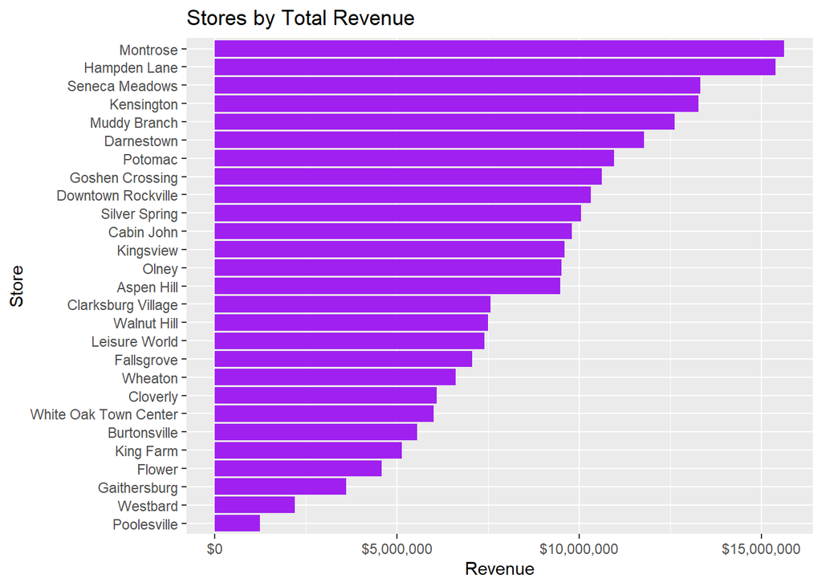

```r
# Total sales per store
store_sales <- transactions %>%
  filter(!IsRefund) %>%
  group_by(STORENAME) %>%
  summarise(TotalSales = sum(NETAMOUNT, na.rm = TRUE)) %>%
  arrange(desc(TotalSales))

# Rank stores by revenue
ggplot(store_sales, aes(x = reorder(STORENAME, TotalSales), y = TotalSales)) +
  geom_col(fill = "purple") +
  coord_flip() +
  labs(
    title = "Stores by Total Revenue",
    x     = "Store",
    y     = "Revenue"
  ) +
  scale_y_continuous(labels = dollar)
```

# Interpretation: Store Revenue

Total revenue is highly concentrated among a subset of stores, with a clear drop-off beyond the top-ranked locations. This dispersion suggests that system-wide performance is disproportionately influenced by a small number of high-volume stores, while the median store operates at a substantially lower revenue level. These differences motivate normalization by square footage and traffic in later sections to distinguish scale effects from true productivity differences.

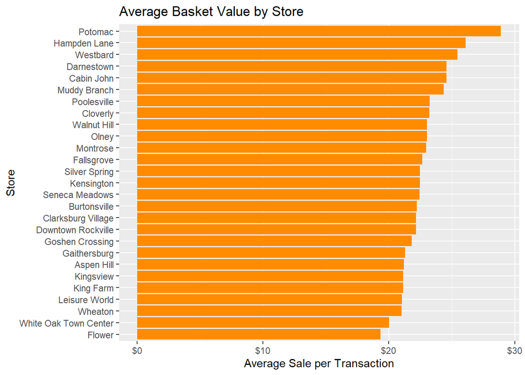

```r
# Average ticket per store (sales per transaction)
store_eff <- transactions %>%
  filter(!IsRefund) %>%
  group_by(STORENAME) %>%
  summarise(
    TotalSales    = sum(NETAMOUNT, na.rm = TRUE),
    Transactions  = n(),
    AvgTicket     = TotalSales / Transactions
  ) %>%
  arrange(desc(AvgTicket))

ggplot(store_eff, aes(x = reorder(STORENAME, AvgTicket), y = AvgTicket)) +
  geom_col(fill = "darkorange") +
  coord_flip() +
  labs(
    title = "Average Basket Value by Store",
    x     = "Store",
    y     = "Average Sale per Transaction"
  ) +
  scale_y_continuous(labels = dollar)
```

# Interpretation: Average Ticket Size

Average basket value varies meaningfully across stores and does not closely mirror the revenue ranking. Several high-revenue stores do not exhibit the highest average ticket sizes, implying that revenue leadership is often driven by transaction volume rather than per-transaction spend. Conversely, some lower-revenue stores achieve relatively high basket values but lack sufficient traffic to translate this into high total sales.

# 4. Top Items (Quantity & Revenue)

To identify key products driving sales, item-level performance is evaluated using both quantity sold and total revenue. Ranking items by quantity highlights high-volume products that contribute to traffic and repeat purchases, while ranking by revenue emphasizes higher-priced or premium products that disproportionately affect total sales. Together, these views provide a balanced understanding of product performance across volume and value dimensions.

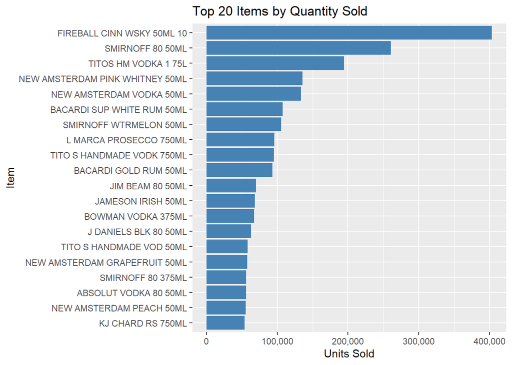

```r
# Top items by units sold
top_items_qty <- transactions %>%
  filter(!IsRefund) %>%
  group_by(DESCRIPTION) %>%
  summarise(UnitsSold = sum(LINEQTY, na.rm = TRUE)) %>%
  arrange(desc(UnitsSold)) %>%
  head(20)

ggplot(top_items_qty,
       aes(x = reorder(DESCRIPTION, UnitsSold), y = UnitsSold)) +
  geom_col(fill = "steelblue") +
  coord_flip() +
  labs(
    title = "Top 20 Items by Quantity Sold",
    x     = "Item",
    y     = "Units Sold"
  ) +
  scale_y_continuous(labels = comma)
```

# Interpretation: Top Items by Quantity

Unit sales are highly concentrated among a small number of products, consistent with a classic “core SKU” structure. These high-volume items account for a disproportionate share of transaction units despite representing a small fraction of total assortment. Their dominance implies that availability and replenishment reliability for these items are likely to have an outsized effect on customer satisfaction and repeat visits.

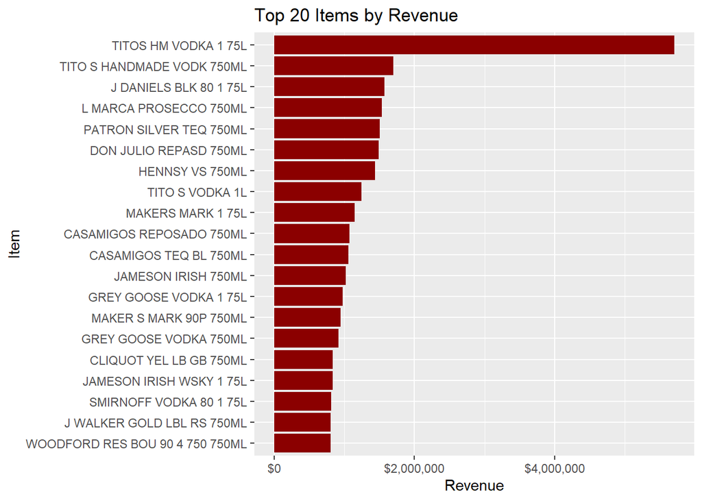

```r
# Top items by revenue
top_items_rev <- transactions %>%
  filter(!IsRefund) %>%
  group_by(DESCRIPTION) %>%
  summarise(Revenue = sum(NETAMOUNT, na.rm = TRUE)) %>%
  arrange(desc(Revenue)) %>%
  head(20)

ggplot(top_items_rev,
       aes(x = reorder(DESCRIPTION, Revenue), y = Revenue)) +
  geom_col(fill = "darkred") +
  coord_flip() +
  labs(
    title = "Top 20 Items by Revenue",
    x     = "Item",
    y     = "Revenue"
  ) +
  scale_y_continuous(labels = dollar)
```

# Interpretation: Top Items by Revenue

The set of highest-revenue items differs noticeably from the highest-volume items, reflecting the role of price and product tier in revenue generation. This divergence indicates that revenue performance depends jointly on volume and price, reinforcing the need to analyze both quantity-driven and value-driven products when evaluating assortment effectiveness.

# 5. Category-Level EDA (Department & Type)

This section aggregates sales at the category level to assess performance across major product groupings. Revenue is summarized by classification type and department to identify which segments contribute most to overall sales. Category-level analysis helps contextualize store and item-level results by revealing structural differences in demand across product classes.

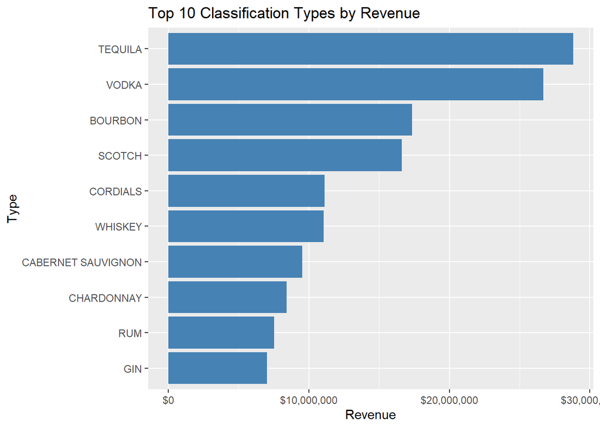

```r
# Top classification types by revenue
transactions %>%
  filter(!IsRefund) %>%
  group_by(CLASSIFICATIONTYPE) %>%
  summarise(TotalSales = sum(NETAMOUNT, na.rm = TRUE)) %>%
  arrange(desc(TotalSales)) %>%
  head(10) %>%
  ggplot(aes(x = reorder(CLASSIFICATIONTYPE, TotalSales), y = TotalSales)) +
  geom_col(fill = "steelblue") +
  coord_flip() +
  labs(
    title = "Top 10 Classification Types by Revenue",
    x     = "Type",
    y     = "Revenue"
  ) +
  scale_y_continuous(labels = dollar)
```

# Interpretation: Top Classification Types

Sales concentration in the top classification types suggests that a limited number of product types drive a large portion of revenue. This pattern helps prioritize category focus when analyzing mix differences across stores or designing store-level assortment strategies.

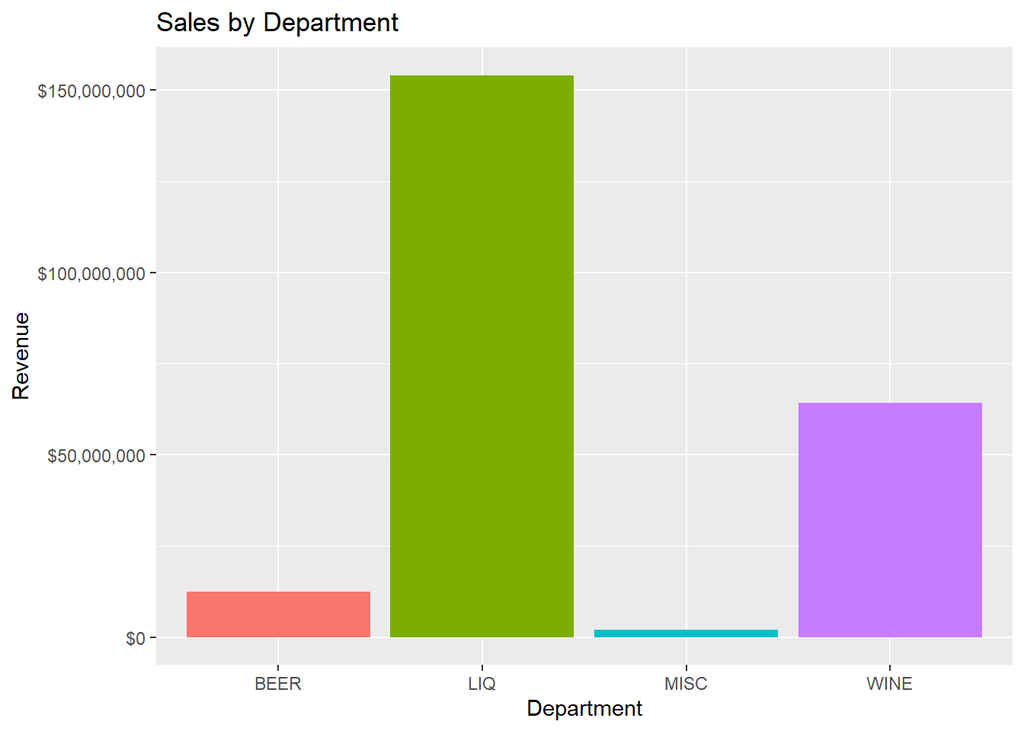

```r
# Revenue split by major department
transactions %>%
  filter(!IsRefund) %>%
  group_by(CLASSIFICATIONDEPARTMENT) %>%
  summarise(TotalSales = sum(NETAMOUNT, na.rm = TRUE)) %>%
  ggplot(aes(x = CLASSIFICATIONDEPARTMENT, y = TotalSales, fill = CLASSIFICATIONDEPARTMENT)) +
  geom_col() +
  labs(
    title = "Sales by Department",
    x     = "Department",
    y     = "Revenue"
  ) +
  scale_y_continuous(labels = dollar) +
  theme(legend.position = "none")
```

# Interpretation: Department Sales Mix

Revenue is unevenly distributed across major departments, with liquor accounting for the dominant share of total sales, followed by wine and beer, and a minimal contribution from miscellaneous items. Because department shares vary across stores, this structural mix difference has direct implications for sales per square foot and must be controlled for in store-level comparisons. Treating stores as homogeneous without accounting for mix would confound productivity with category composition.

# 6. Price Distribution (FEE = Price per Line Unit)

Unit-level pricing behavior is examined by analyzing the distribution of transaction prices per unit. Prices are calculated as net sales divided by quantity and are capped at the 99th percentile to reduce the influence of extreme outliers. Both overall price distributions and department-level comparisons are used to evaluate pricing variability and differences in typical unit prices across product categories.

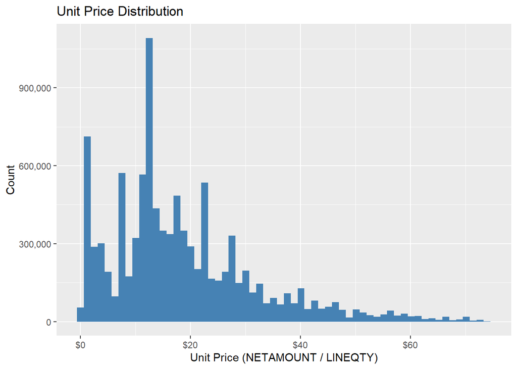

```r
# Overall unit price distribution (capped at 99th percentile)
transactions %>%
  filter(!IsRefund, !is.na(FEE), FEE > 0, FEE < quantile(FEE, 0.99, na.rm = TRUE)) %>%
  ggplot(aes(FEE)) +
  geom_histogram(bins = 60, fill = "steelblue") +
  labs(
    title = "Unit Price Distribution",
    x     = "Unit Price (NETAMOUNT / LINEQTY)",
    y     = "Count"
  )+
  scale_y_continuous(labels = comma) +
  scale_x_continuous(labels = scales::dollar)
```

# Interpretation: Unit Price Distribution

Unit prices show a skewed distribution, with most purchases concentrated at lower price points and a smaller number of high-priced transactions in the tail. Capping at the 99th percentile reduces the influence of extreme values and provides a clearer view of typical pricing behavior.

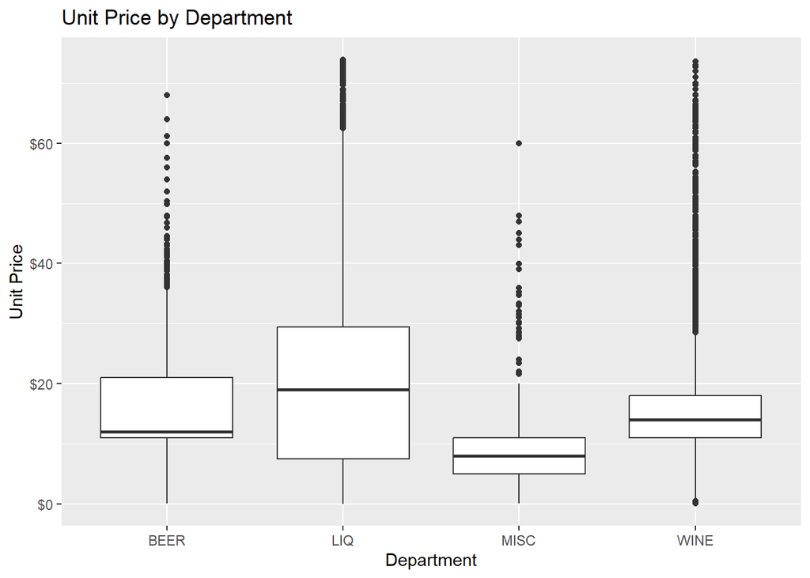

```r
# Price distribution by department
transactions %>%
  filter(!IsRefund, !is.na(FEE), FEE > 0,
         FEE < quantile(FEE, 0.99, na.rm = TRUE)) %>%
  ggplot(aes(x = CLASSIFICATIONDEPARTMENT, y = FEE)) +
  geom_boxplot() +
  labs(
    title = "Unit Price by Department",
    x     = "Department",
    y     = "Unit Price"
  ) +
  scale_y_continuous(labels = scales::dollar)
```

# Interpretation: Price by Department

Unit prices vary by department, indicating that departments differ in typical price levels and price dispersion. This matters for interpreting revenue patterns, since higher department revenue may reflect higher prices, higher volume, or both.

# 7. Year Subsets (FY23–24 and FY24–25)

To enable consistent year-over-year comparison, transaction data are segmented into two fiscal-year subsets: FY23–24 and FY24–25. Fiscal years are defined using July 1 as the start date and June 30 as the end date, aligning the analysis with standard public-sector reporting conventions. In addition, the enriched transaction dataset containing day-type classifications is similarly filtered to the FY24–25 period to support subsequent temporal and store-level analysis within a consistent time frame.

```r
# Filter transactions into fiscal years
y24_25 <- transactions %>%
  filter(
    TRANSDATE >= as.Date("2024-07-01"),
    TRANSDATE <= as.Date("2025-06-30")
  )

y23_24 <- transactions %>%
  filter(
    TRANSDATE >= as.Date("2023-07-01"),
    TRANSDATE <= as.Date("2024-06-30")
  )

# Holiday/daytype subset for FY24–25
transactionsFS_fy <- transactionsFS %>%
  filter(
    TRANSDATE >= as.Date("2024-07-01"),
    TRANSDATE <= as.Date("2025-06-30")
  )

transactionsFS %>%
  count(DayType)
```

```
##   DayType       n
## 1 Holiday   59073
## 2 Weekday 7111358
## 3 Weekend 3019959
```

# 8. Store-Level KPIs (Sales, Traffic, Baskets, per SqFt)

```r
# Core store-level KPIs for Y24–25
store_summary <- transactions %>%
  filter(!IsRefund) %>%
  group_by(STORENAME) %>%
  summarise(
    TotalSales        = sum(NETAMOUNT, na.rm = TRUE),
    TotalTransactions = n(),
    TotalBaskets      = n_distinct(TRANSACTIONID),
    .groups           = "drop"
  )

# Add store square footage
store_sqft <- designation %>%
  mutate(STORENAME = trimws(STORENAME)) %>%
  select(STORENAME, SquareFootage)

store_summary <- store_summary %>%
  left_join(store_sqft, by = "STORENAME") %>%
  mutate(
    TotalSalesPerSqFt        = TotalSales / SquareFootage,
    TotalTransactionsPerSqFt = TotalTransactions / SquareFootage,
    TotalBasketsPerSqFt      = TotalBaskets / SquareFootage,
    Avg_BasketValue          = TotalSales / TotalBaskets
  )

# Basket-level metrics at store level
basket_metrics <- transactions %>%
  filter(!IsRefund) %>%
  group_by(STORENAME, TRANSACTIONID) %>%
  summarise(
    BasketTotal = sum(NETAMOUNT, na.rm = TRUE),
    Items       = sum(LINEQTY,   na.rm = TRUE),
    .groups     = "drop"
  )

basket_summary <- basket_metrics %>%
  group_by(STORENAME) %>%
  summarise(
    AvgBasketValue    = mean(BasketTotal, na.rm = TRUE),
    AvgItemsPerBasket = mean(Items,       na.rm = TRUE),
    .groups           = "drop"
  )

# Attach basket metrics back to store KPIs
store_summary <- store_summary %>%
  left_join(basket_summary, by = "STORENAME")
```